# Self-Driving Car Engineer Nanodegree | Deep Learning

## Project: Build a Traffic Sign Recognition Classifier

### by Mohit Arvind Khakharia

## Import Statements

```python
import pickle
import matplotlib.pyplot as plt
import cv2
import csv
import numpy as np
from numpy import newaxis
from sklearn.utils import shuffle
import tensorflow as tf
from tensorflow.contrib.layers import flatten
import random
import matplotlib.image as mpimg
import os
%matplotlib inline
```

## Step 0: Load The Data

```python
#All the images are loaded from the pickle files
training_file = "./data/train.p"
validation_file = "./data/valid.p"
testing_file = "./data/test.p"


with open(training_file, mode='rb') as f:
    train = pickle.load(f)
with open(validation_file, mode='rb') as f:
    valid = pickle.load(f)
with open(testing_file, mode='rb') as f:
    test = pickle.load(f)

# Six different arrays are created. Two each for training, validation and testing.
X_train, y_train = train['features'], train['labels']
X_valid, y_valid = valid['features'], valid['labels']
X_test, y_test = test['features'], test['labels']

#The shapes of the image arrays are printed before data augmentation.
print("BEFORE DATA AUGMENTATION")
print("X_train shape:", X_train.shape)
print("y_train shape:", y_train.shape)

print("\nX_valid shape:", X_valid.shape)
print("y_valid shape:", y_valid.shape)

print("\nX_test shape:", X_test.shape)
print("y_test shape:", y_test.shape)

csv_obj = {}
with open('signnames.csv', 'rt') as csvfile:
    reader = csv.reader(csvfile, delimiter=',')
    for row in reader:
        if (row[0]!='ClassId'):
            csv_obj[int(row[0])] = row[1]

print ("\nThe different traffic signs are - ")
print (csv_obj)

print ("\nTotal number of traffic signs - ")
print (len(csv_obj))
```

```
BEFORE DATA AUGMENTATION
X_train shape: (34799, 32, 32, 3)
y_train shape: (34799,)

X_valid shape: (4410, 32, 32, 3)
y_valid shape: (4410,)

X_test shape: (12630, 32, 32, 3)
y_test shape: (12630,)

The different traffic signs are -
{0: 'Speed limit (20km/h)', 1: 'Speed limit (30km/h)', 2: 'Speed limit (50km/h)', 3: 'Speed limit (60km/h)', 4: 'Speed limit (70km/h)', 5: 'Speed limit (80km/h)', 6: 'End of speed limit (80km/h)', 7: 'Speed limit (100km/h)', 8: 'Speed limit (120km/h)', 9: 'No passing', 10: 'No passing for vehicles o…

Total number of traffic signs -
43
```

## Step 1: Data Augmentation

### Trasnformations Applied

```python
'''
As mentioned in the lecutre, it is always a good practice to augment the data before training inorder to achieve translationaly,
rotational and brightness invariance.
- Rotation
- Shear
- Zoom
- Translation
'''
def augment_data(dataset, dataset_labels, augementation_factor=1, use_random_rotation=True, use_random_shear=False, use_random_shift=False, use_random_zoom=False):
    augmented_image = []
    augmented_image_labels = []

    for num in range (0, dataset.shape[0]):

        for i in range(0, augementation_factor):
            # original image:
            augmented_image.append(dataset[num])
            augmented_image_labels.append(dataset_labels[num])

            if use_random_rotation:
                augmented_image.append(tf.contrib.keras.preprocessing.image.random_rotation(dataset[num], 20, row_axis=0, col_axis=1, channel_axis=2))
                augmented_image_labels.append(dataset_labels[num])

            if use_random_shear:
                augmented_image.append(tf.contrib.keras.preprocessing.image.random_shear(dataset[num], 0.2, row_axis=0, col_axis=1, channel_axis=2))
                augmented_image_labels.append(dataset_labels[num])

            if use_random_shift:
                augmented_image.append(tf.contrib.keras.preprocessing.image.random_shift(dataset[num], 0.2, 0.2, row_axis=0, col_axis=1, channel_axis=2))
                augmented_image_labels.append(dataset_labels[num])

            if use_random_zoom:
                augmented_image.append(tf.contrib.keras.preprocessing.image.random_zoom(dataset[num], 0.9, row_axis=0, col_axis=1, channel_axis=2))
                augmented_image_labels.append(dataset_labels[num])

    return np.array(augmented_image), np.array(augmented_image_labels)

X_train,y_train=augment_data(X_train,y_train,augementation_factor=1)
X_valid,y_valid=augment_data(X_valid,y_valid, augementation_factor=2)

print("\nAugemented_X_train.shape:", X_train.shape)
print("Augemented_y_train shape:", y_train.shape)

print("\nAugemented_X_valid.shape:", X_valid.shape)
print("Augemented_y_valid:", y_valid.shape)
```

```
Augemented_X_train.shape: (69598, 32, 32, 3)
Augemented_y_train shape: (69598,)

Augemented_X_valid.shape: (17640, 32, 32, 3)
Augemented_y_valid: (17640,)
```

## Step 2: Dataset Summary & Exploration

The pickled data is a dictionary with 4 key/value pairs:

- `'features'` is a 4D array containing raw pixel data of the traffic sign images, (num examples, width, height, channels).
- `'labels'` is a 1D array containing the label/class id of the traffic sign. The file `signnames.csv` contains id -> name mappings for each id.
- `'sizes'` is a list containing tuples, (width, height) representing the original width and height the image.
- `'coords'` is a list containing tuples, (x1, y1, x2, y2) representing coordinates of a bounding box around the sign in the image. THESE COORDINATES ASSUME THE ORIGINAL IMAGE. THE PICKLED DATA CONTAINS RESIZED VERSIONS (32 by 32) OF THESE IMAGES.

### Basic Summary of the Data Set

```python
### Replace each question mark with the appropriate value.
### Use python, pandas or numpy methods rather than hard coding the results

# TODO: Number of training examples
n_train =  X_train.shape[0]

# TODO: Number of validation examples
n_validation =  X_valid.shape[0]

# TODO: Number of testing examples.
n_test =  X_test.shape[0]

# TODO: What's the shape of an traffic sign image?
image_shape = X_train[0].shape

# TODO: How many unique classes/labels there are in the dataset.
n_classes = len(csv_obj)

print("Number of training examples =", n_train)
print("Number of testing examples =", n_test)
print("Image data shape =", image_shape)
print("Number of classes =", n_classes)
```

```
Number of training examples = 69598
Number of testing examples = 12630
Image data shape = (32, 32, 3)
Number of classes = 43
```

### Visualization of the dataset

A visualization of the augmented random sample data is shown below.

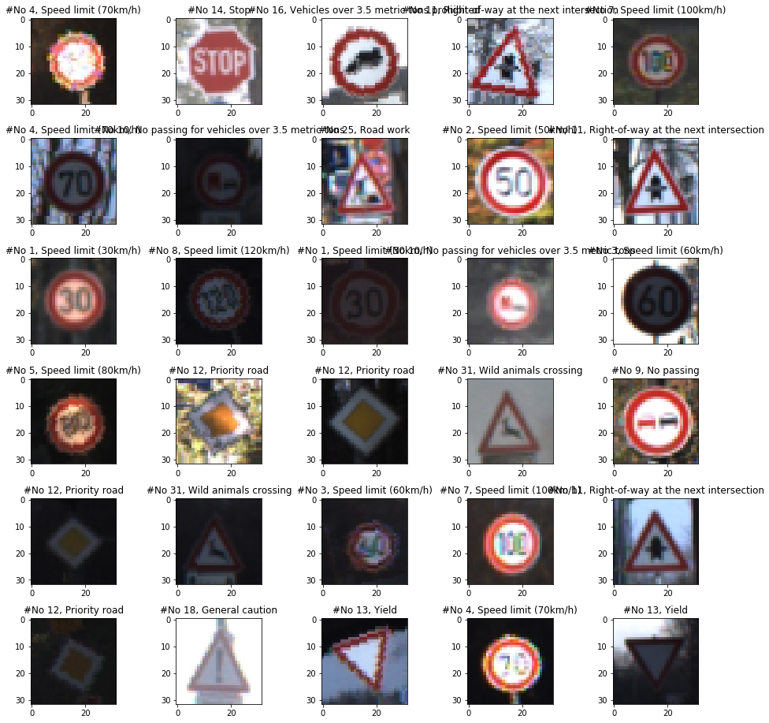

```python
### Data exploration visualization code goes here.
### Feel free to use as many code cells as needed.

plt.figure(figsize=(16,16))
plt.subplots_adjust(hspace = .4)
for i in range(30):
    sub = plt.subplot(6,5,i+1)
    rand = random.randint(0, n_train)
    plt.imshow(X_train[rand])
#     plt.tight_layout()
    sub.set_title("#No %s, %s" % ( y_train[rand],csv_obj[y_train[rand]]))
```

## Statistical Analysis of the Class frequency

- Tells us if we have enough samples of all the classes
- Tells us if our training data is not biased
- Tells us that if we cover all the classes in the Validation set
- Tells us if we test all the classes in the Test set

```
TRAINING DATA - FREQUENCY PER CLASS
{0: 360, 1: 3960, 2: 4020, 3: 2520, 4: 3540, 5: 3300, 6: 720, 7: 2580, 8: 2520, 9: 2640, 10: 3600, 11: 2340, 12: 3780, 13: 3840, 14: 1380, 15: 1080, 16: 720, 17: 1980, 18: 2160, 19: 360, 20: 600, 21: 540, 22: 660, 23: 900, 24: 480, 25: 2700, 26: 1080, 27: 420, 28: 960, 29: 480, 30: 780, 31: 1380, 32…

VALIDATION DATA - FREQUENCY PER CLASS
{0: 120, 1: 960, 2: 960, 3: 600, 4: 840, 5: 840, 6: 240, 7: 600, 8: 600, 9: 600, 10: 840, 11: 600, 12: 840, 13: 960, 14: 360, 15: 360, 16: 240, 17: 480, 18: 480, 19: 120, 20: 240, 21: 240, 22: 240, 23: 240, 24: 120, 25: 600, 26: 240, 27: 120, 28: 240, 29: 120, 30: 240, 31: 360, 32: 120, 33: 360, 34:…

TESTING DATA - FREQUENCY PER CLASS
{0: 60, 1: 720, 2: 750, 3: 450, 4: 660, 5: 630, 6: 150, 7: 450, 8: 450, 9: 480, 10: 660, 11: 420, 12: 690, 13: 720, 14: 270, 15: 210, 16: 150, 17: 360, 18: 390, 19: 60, 20: 90, 21: 90, 22: 120, 23: 150, 24: 90, 25: 480, 26: 180, 27: 60, 28: 150, 29: 90, 30: 150, 31: 270, 32: 60, 33: 210, 34: 120, 35…
```

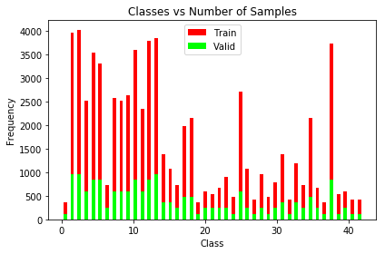

```python
unique_train, counts_train = np.unique(y_train, return_counts=True)
unique_validation, counts_validation = np.unique(y_valid, return_counts=True)
unique_test, counts_test = np.unique(test['labels'], return_counts=True)

print("\nTRAINING DATA - FREQUENCY PER CLASS")
print(dict(zip(unique_train, counts_train)))

print("\nVALIDATION DATA - FREQUENCY PER CLASS")
print(dict(zip(unique_validation, counts_validation)))

print("\nTESTING DATA - FREQUENCY PER CLASS")
print(dict(zip(unique_test, counts_test)))

fig, axes = plt.subplots(nrows=1, ncols=1)
axes.hist(y_train, n_classes, histtype='bar', color='red', label=["Train"],rwidth=0.5)
# axes.hist(test['labels'], n_classes, histtype='bar', color='cyan', label=["Test"],rwidth=0.5)
axes.hist(y_valid, n_classes, histtype='bar', color='lime', label=["Valid"],rwidth=0.5)
axes.legend(prop={'size': 10})
axes.set_title('Classes vs Number of Samples')
plt.xlabel('Class')
plt.ylabel('Frequency')

fig_size = plt.rcParams["figure.figsize"]
# Shows the figure size
# print(fig_size)

fig_size[0] = 8
fig_size[1] = 2
plt.rcParams["figure.figsize"] = fig_size
fig.tight_layout()
plt.tight_layout()
plt.show()
```

## Step 3: Design and Test a Model Architecture

- Deep learning model that learns to recognize traffic signs.
- Dataset [German Traffic Sign Dataset](http://benchmark.ini.rub.de/?section=gtsrb&subsection=dataset).
- LeNet-5 implementation shown in the classroom.

### Problem Aspects

- Neural network architecture (is the network over or underfitting?)
- Played around preprocessing techniques (normalization, rgb to grayscale, etc)
- Number of examples per label (some have more than others).
- Generated fake data.

### Pre-process the Data Set (normalization, grayscale, etc.)

### Steps Applied

- Normalized the data has mean zero and equal variance by using the following formula - `(pixel - 128)/ 128`
- Converted to grayscale by averaging the channels.
- Shuffled the data for preventing a biased learning curve when using batch based Gradient algorithms as they assume the batch is an approximation of the entire dataset.

```
Training Data Shape - Before Preprocessing
(69598, 32, 32, 3)
Training Data Shape - After Preprocessing
(69598, 32, 32, 1)
Validation Data Shape - Before Preprocessing
(17640, 32, 32, 3)
Validation Data Shape - After Preprocessing
(17640, 32, 32, 1)
Testing Data Shape - Before Preprocessing
(12630, 32, 32, 3)
Testing Data Shape - After Preprocessing
(12630, 32, 32, 1)
```

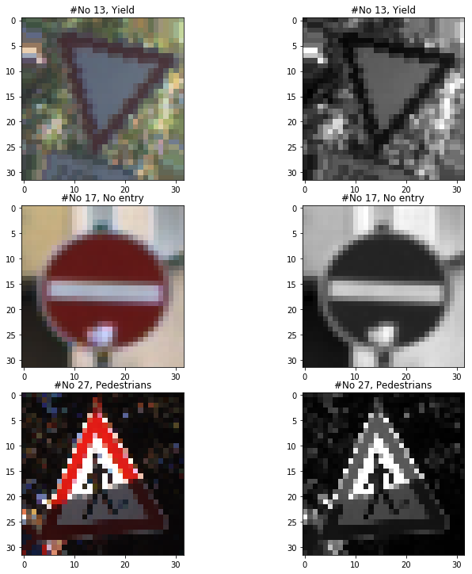

```python
### Preprocess the data here.

#Shuffling the data
X_train, y_train = shuffle(X_train, y_train)

#Formula to convert an rgb image array to grayscale
#Not following the exact formula of --> Gray_Image = 0.299r + 0.587g + 0.114b but instead averaging the pixels.
def convert_to_gray(image_array):
    return np.sum(image_array/3, axis=3, keepdims=True)

#Normalizing the data
def normalize(image_array):
    return np.divide(np.subtract(image_array,128.),128.)

#Entire Preprocess function
def preprocess(image_array):
    image_array_gray = convert_to_gray(image_array)
    image_array_normalized = normalize(image_array_gray)
    return image_array_normalized

#Preprocess Training Data
preprocessed_train_x=preprocess(X_train)

#Preprocess Validation Data
preprocessed_valid_x=preprocess(X_valid)

#Preprocess Testing Data
preprocessed_test_x=preprocess(X_test)

print("Training Data Shape - Before Preprocessing")
print(X_train.shape)
print("Training Data Shape - After Preprocessing")
print(preprocessed_train_x.shape)

print("Validation Data Shape - Before Preprocessing")
print(X_valid.shape)
print("Validation Data Shape - After Preprocessing")
print(preprocessed_valid_x.shape)

print("Testing Data Shape - Before Preprocessing")
print(X_test.shape)
print("Testing Data Shape - After Preprocessing")
print(preprocessed_test_x.shape)

#Dropping the last dimension to make it work in matplot lib's imshow function
preprocessed_train_x_display = np.squeeze(preprocessed_train_x, axis=(3,))
preprocessed_test_x_display = np.squeeze(preprocessed_test_x, axis=(3,))
preprocessed_valid_x_display = np.squeeze(preprocessed_valid_x, axis=(3,))

fig, axs = plt.subplots(3,2, figsize=(10, 10))
fig.subplots_adjust(hspace = .1, wspace=.000)
axs = axs.ravel()
plt.tight_layout()

#Display Random sample before and after pre-processing - Training Data
index = random.randint(0, len(X_train))
axs[0].imshow(X_train[index])
axs[0].set_title("#No %s, %s" % ( y_train[index],csv_obj[y_train[index]]))
axs[1].imshow(preprocessed_train_x_display[index], cmap='gray')
axs[1].set_title("#No %s, %s" % ( y_train[index],csv_obj[y_train[index]]))

#Display Random sample before and after pre-processing - Validation Data
index = random.randint(0, len(X_valid))
axs[2].imshow(X_valid[index])
axs[2].set_title("#No %s, %s" % ( y_valid[index],csv_obj[y_valid[index]]))
axs[3].imshow(preprocessed_valid_x_display[index], cmap='gray')
axs[3].set_title("#No %s, %s" % ( y_valid[index],csv_obj[y_valid[index]]))

#Display Random sample before and after pre-processing - Testing Data
index = random.randint(0, len(X_test))
axs[4].imshow(X_test[index])
axs[4].set_title("#No %s, %s" % ( y_test[index],csv_obj[y_test[index]]))
axs[5].imshow(preprocessed_test_x_display[index], cmap='gray')
axs[5].set_title("#No %s, %s" % ( y_test[index],csv_obj[y_test[index]]))
```

### Model Architecture

A modified version of Lenet has been implemented.

### Changes to Lenet Architecture

- Kernel size : 5
- Number of Classes : 43
- Number of color channels : 1
- Changed the size of the different convoulutional, relu, max-pool and fully connected layers.

```python
def LeNet(x):
    # Arguments used for tf.truncated_normal, randomly defines variables for the weights and biases for each layer
    mu = 0
    sigma = 0.1
    kernel_size = 5
    num_colors = 1
    depth = 6
    num_classes=43

    # SOLUTION: Layer 1: Convolutional. Input = 32x32x1. Output = 28x28x6.
    conv1_W = tf.Variable(tf.truncated_normal(shape=(kernel_size, kernel_size, num_colors, depth), mean = mu, stddev = sigma))
    conv1_b = tf.Variable(tf.zeros(depth))
    conv1   = tf.nn.conv2d(x, conv1_W, strides=[1, 1, 1, 1], padding='VALID') + conv1_b
    print ("After conv1 shape:", conv1.get_shape())

    # SOLUTION: Activation.
    conv1 = tf.nn.relu(conv1)
    print ("After conv1 and relu shape:", conv1.get_shape())

    # SOLUTION: Pooling. Input = 28x28x6. Output = 14x14x6.
    conv1 = tf.nn.max_pool(conv1, ksize=[1, 2, 2, 1], strides=[1, 2, 2, 1], padding='VALID')
    print ("After conv1 relu and maxpool shape:", conv1.get_shape())

    # SOLUTION: Layer 2: Convolutional. Output = 10x10x16.
    conv2_W = tf.Variable(tf.truncated_normal(shape=(5, 5, 6, 16), mean = mu, stddev = sigma))
    conv2_b = tf.Variable(tf.zeros(16))
    conv2   = tf.nn.conv2d(conv1, conv2_W, strides=[1, 1, 1, 1], padding='VALID') + conv2_b

    print ("After conv2 shape:", conv2.get_shape())
    # SOLUTION: Activation.
    conv2 = tf.nn.relu(conv2)
    print ("After conv2 relu shape:", conv2.get_shape())

    # SOLUTION: Pooling. Input = 10x10x16. Output = 5x5x16.
    conv2 = tf.nn.max_pool(conv2, ksize=[1, 2, 2, 1], strides=[1, 2, 2, 1], padding='VALID')
    print ("After conv2 relu and max pool shape:", conv2.get_shape())

    # SOLUTION: Flatten. Input = 5x5x16. Output = 400.
    fc0   = flatten(conv2)

    print ("After flattening shape:", fc0.get_shape())
    # SOLUTION: Layer 3: Fully Connected. Input = 400. Output = 200.
    fc1_W = tf.Variable(tf.truncated_normal(shape=(400, 200), mean = mu, stddev = sigma))
    fc1_b = tf.Variable(tf.zeros(200))
    fc1   = tf.matmul(fc0, fc1_W) + fc1_b

    # SOLUTION: Activation.
    fc1    = tf.nn.relu(fc1)
    print ("After fully convolutionaly layer 1 shape:", fc1.get_shape())

    # SOLUTION: Layer 4: Fully Connected. Input = 200. Output = 100.
    fc2_W  = tf.Variable(tf.truncated_normal(shape=(200, 100), mean = mu, stddev = sigma))
    fc2_b  = tf.Variable(tf.zeros(100))
    fc2    = tf.matmul(fc1, fc2_W) + fc2_b

    # SOLUTION: Activation.
    fc2    = tf.nn.relu(fc2)
    print ("After fully convolutionaly layer 2 shape:", fc2.get_shape())

    # SOLUTION: Layer 5: Fully Connected. Input = 100. Output = 43.
    fc3_W  = tf.Variable(tf.truncated_normal(shape=(100, num_classes), mean = mu, stddev = sigma))
    fc3_b  = tf.Variable(tf.zeros(num_classes))
    logits = tf.matmul(fc2, fc3_W) + fc3_b
    print ("logits shape:", logits.get_shape())
    return logits
```

### Train, Validate and Test the Model

- A validation set can be used to assess how well the model is performing.
- A low accuracy on the training and validation sets imply underfitting. A high accuracy on the training set but low accuracy on the validation set implies overfitting.

### Hyper Parameters

- Batch Size 128
- Epochs - 100
- Learning rate - 0.001 Played around with different values of the hyperparameters and the above mentioned ones seems to be the best fit.

```python
EPOCHS = 100
BATCH_SIZE = 128

x = tf.placeholder(tf.float32, (None, 32, 32, 1))
y = tf.placeholder(tf.int32, (None))
one_hot_y = tf.one_hot(y, 43)

keep_prob = tf.placeholder(tf.float32)
learning_rate = 0.001
logits = LeNet(x)

# print("logits")
# print(logits)

cross_entropy = tf.nn.softmax_cross_entropy_with_logits(logits=logits, labels=one_hot_y)
loss_operation = tf.reduce_mean(cross_entropy)
optimizer = tf.train.AdamOptimizer(learning_rate = learning_rate)
training_operation = optimizer.minimize(loss_operation)

correct_prediction = tf.equal(tf.argmax(logits, 1), tf.argmax(one_hot_y, 1))
accuracy_operation = tf.reduce_mean(tf.cast(correct_prediction, tf.float32))
saver = tf.train.Saver()

def evaluate(X_data, y_data):
    num_examples = len(X_data)
    total_accuracy = 0
    sess = tf.get_default_session()
    for offset in range(0, num_examples, BATCH_SIZE):
        batch_x, batch_y = X_data[offset:offset+BATCH_SIZE], y_data[offset:offset+BATCH_SIZE]
        accuracy = sess.run(accuracy_operation, feed_dict={x: batch_x, y: batch_y})
        total_accuracy += (accuracy * len(batch_x))
    return total_accuracy / num_examples

with tf.Session() as sess:
    sess.run(tf.global_variables_initializer())
    num_examples = len(X_train)

    print("Training...")
    print()
    for i in range(EPOCHS):
        for offset in range(0, num_examples, BATCH_SIZE):
            end = offset + BATCH_SIZE
            batch_x, batch_y = preprocessed_train_x[offset:end], y_train[offset:end]
            sess.run(training_operation, feed_dict={x: batch_x, y: batch_y})

        validation_accuracy = evaluate(preprocessed_valid_x, y_valid)
        print("EPOCH {} ...".format(i+1))
        print("Validation Accuracy = {:.3f}".format(validation_accuracy))

    saver.save(sess, './lenet')
    print("Model saved")
```

```
After conv1 shape: (?, 28, 28, 6)
After conv1 and relu shape: (?, 28, 28, 6)
After conv1 relu and maxpool shape: (?, 14, 14, 6)
After conv2 shape: (?, 10, 10, 16)
After conv2 relu shape: (?, 10, 10, 16)
After conv2 relu and max pool shape: (?, 5, 5, 16)
After flattening shape: (?, 400)
After fully convolutionaly layer 1 shape: (?, 200)
After fully convolutionaly layer 2 shape: (?, 100)
logits shape: (?, 43)
Training...

EPOCH 1 ...
Validation Accuracy = 0.832
EPOCH 2 ...
Validation Accuracy = 0.878
EPOCH 3 ...
Validation Accuracy = 0.892
EPOCH 4 ...
Validation Accuracy = 0.896
EPOCH 5 ...
Validation Accuracy = 0.893
EPOCH 6 ...
Validation Accuracy = 0.908
EPOCH 7 ...
Validation Accuracy = 0.908
EPOCH 8 ...
Validation Accuracy = 0.907
EPOCH 9 ...
Validation Accuracy = 0.909
EPOCH 10 ...
Validation Accuracy = 0.905
EPOCH 11 ...
Validation Accuracy = 0.917
EPOCH 12 ...
Validation Accuracy = 0.915
EPOCH 13 ...
Validation Accuracy = 0.922
EPOCH 14 ...
Validation Accuracy = 0.911
```

[output cut: 158 more lines]

```
EPOCH 94 ...
Validation Accuracy = 0.943
EPOCH 95 ...
Validation Accuracy = 0.934
EPOCH 96 ...
Validation Accuracy = 0.934
EPOCH 97 ...
Validation Accuracy = 0.942
EPOCH 98 ...
Validation Accuracy = 0.943
EPOCH 99 ...
Validation Accuracy = 0.938
EPOCH 100 ...
Validation Accuracy = 0.941
Model saved
```

### Accuracy | Validation Dataset

- Accuracy : 94.1%

### Accuracy | Testing Dataset

- Accuracy : 93.3%

```python
with tf.Session() as sess:
    saver.restore(sess, tf.train.latest_checkpoint('.'))

    test_accuracy = evaluate(preprocessed_test_x, y_test)
    print("Test Accuracy = {:.3f}".format(test_accuracy))
```

```
INFO:tensorflow:Restoring parameters from .\lenet
Test Accuracy = 0.933
```

## Step 4: Test a Model on New Custom Images

### Load and Output the Images

```
['1.png', '2.png', '3.png', '4.png', '5.png']
img_i: 1.png
image.shape  (32, 32, 4)
img_i: 2.png
image.shape  (32, 32, 4)
img_i: 3.png
image.shape  (32, 32, 4)
img_i: 4.png
image.shape  (32, 32, 4)
img_i: 5.png
image.shape  (32, 32, 4)
Gray scaled image shape - (5, 32, 32, 1)
```

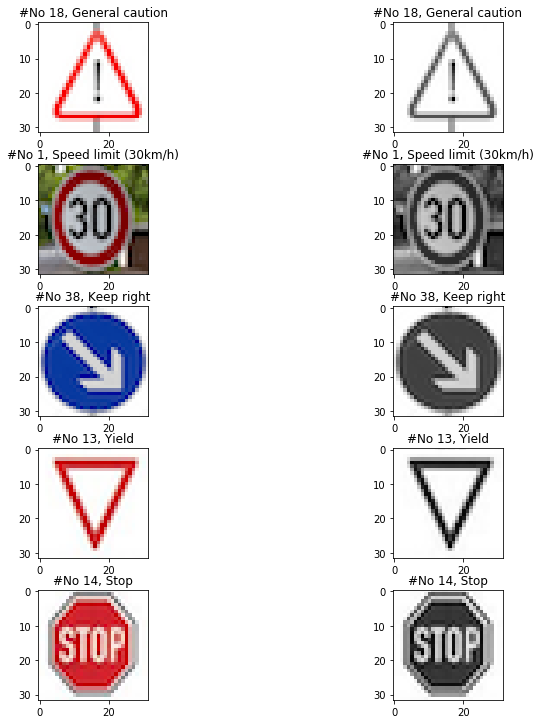

```python
### Load the images and plot them here.
### Feel free to use as many code cells as needed.

custom_imgs = os.listdir(os.getcwd()+"/custom_pics/")
imgage_list = []

print(custom_imgs)
for img_i in custom_imgs:
    print('img_i:',img_i)
    image = mpimg.imread(os.getcwd()+"/custom_pics/"+img_i)
    print ('image.shape ',image.shape)
    resized=cv2.resize(image,(32,32))
    imgage_list.append(resized)

X_custom = np.array(imgage_list)
y_custom=[18,1,38,13,14]
#y_custom=np.array(y_custom_raw)

#Preprocess Custom Test Data

preprocessed_custom_x=convert_to_gray(X_custom)
print("Gray scaled image shape -",preprocessed_custom_x.shape)

preprocessed_custom_x_display = np.squeeze(preprocessed_custom_x, axis=(3,))

fig, axs = plt.subplots(5,2, figsize=(10, 10))
fig.subplots_adjust(hspace = .1, wspace=.000)
axs = axs.ravel()
plt.tight_layout()
j=0
for i in range (0, 5):
    axs[j].imshow(X_custom[i])
    axs[j].set_title("#No %s, %s" % ( y_custom[i],csv_obj[y_custom[i]]))
    axs[j+1].imshow(preprocessed_custom_x_display[i], cmap='gray')
    axs[j+1].set_title("#No %s, %s" % ( y_custom[i],csv_obj[y_custom[i]]))
    j=j+2
```

### Predict the Sign Type for Each Image

- Predicting the top three gueses and displaying them with the confidence percentage / Probability

- tf.nn.top_k used fpr predicting the top 3 guesses for each image.

```
preprocessed_custom_x shape (5, 32, 32, 1)
INFO:tensorflow:Restoring parameters from ./lenet
Image -  0
Guess 1 Probability-  0.976936
Guess 2 Probability-  0.0121746
Guess 3 Probability-  0.0108897
Image -  1
Guess 1 Probability-  1.0
Guess 2 Probability-  7.67467e-13
Guess 3 Probability-  4.498e-26
Image -  2
Guess 1 Probability-  1.0
Guess 2 Probability-  1.82335e-18
Guess 3 Probability-  2.00922e-22
Image -  3
Guess 1 Probability-  1.0
Guess 2 Probability-  0.0
Guess 3 Probability-  0.0
Image -  4
Guess 1 Probability-  1.0
Guess 2 Probability-  2.11481e-07
Guess 3 Probability-  1.78538e-11
```

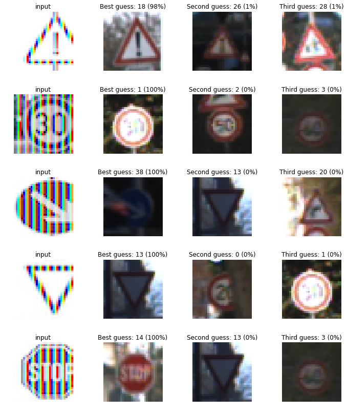

```python
### Run the predictions here and use the model to output the prediction for each image.
print("preprocessed_custom_x shape",preprocessed_custom_x.shape)
softmax_logits = tf.nn.softmax(logits)
top_k = tf.nn.top_k(softmax_logits, k=3)


with tf.Session() as sess:
    sess.run(tf.global_variables_initializer())
    saver = tf.train.import_meta_graph('./lenet.meta')
    saver.restore(sess, "./lenet")
    my_softmax_logits = sess.run(softmax_logits, feed_dict={x: preprocessed_custom_x, keep_prob: 1.0})
    my_top_k = sess.run(top_k, feed_dict={x: preprocessed_custom_x, keep_prob: 1.0})
#     print("Model Predicitions for the custom images")
#     print(my_top_k)
    #Predicting the top three gueses and displaying them with the confidence percentage / Probability
    fig, axs = plt.subplots(len(preprocessed_custom_x),4, figsize=(12, 14))
    fig.subplots_adjust(hspace = .4, wspace=.2)
    axs = axs.ravel()

    for i, image in enumerate(X_custom):
        axs[4*i].axis('off')
        axs[4*i].imshow(cv2.cvtColor(image, cv2.COLOR_BGR2RGB))
        axs[4*i].set_title('input')
        guess1 = my_top_k[1][i][0]
        print("Image - ",i)
        print("Guess 1 Probability- ",my_top_k[0][i][0])
        index1 = np.argwhere(y_valid == guess1)[0]
        axs[4*i+1].axis('off')
        axs[4*i+1].imshow(X_valid[index1].squeeze(), cmap='gray')
        axs[4*i+1].set_title('Best guess: {} ({:.0f}%)'.format(guess1, 100*my_top_k[0][i][0]))
        guess2 = my_top_k[1][i][1]
        print("Guess 2 Probability- ",my_top_k[0][i][1])
        index2 = np.argwhere(y_valid == guess2)[0]
        axs[4*i+2].axis('off')
        axs[4*i+2].imshow(X_valid[index2].squeeze(), cmap='gray')
        axs[4*i+2].set_title('Second guess: {} ({:.0f}%)'.format(guess2, 100*my_top_k[0][i][1]))
        guess3 = my_top_k[1][i][2]
        print("Guess 3 Probability- ",my_top_k[0][i][2])
        index3 = np.argwhere(y_valid == guess3)[0]
        axs[4*i+3].axis('off')
        axs[4*i+3].imshow(X_valid[index3].squeeze(), cmap='gray')
        axs[4*i+3].set_title('Third guess: {} ({:.0f}%)'.format(guess3, 100*my_top_k[0][i][2]))
```

## RESULT

Finaly Validation Accuracy = 94.1%